# Project 1: Duolingo Spaced Repetition Data

Author

Vivian O

### **IMPORTANT BEFORE STARTING:**

If you do not have yet, please download the data set from the source below and add it to your working folder.

**Source:** https://www.kaggle.com/datasets/aravinii/duolingo-spaced-repetition-data?resource=download

“Duolingo is an American educational technology company that produces learning apps and provides language certification. There main app is considered the most popular language learning app in the world.

To progress in their learning journey, each user of the application needs to complete a set of lessons in which they are presented with the words of the language they want to learn. In an infinite set of lessons, each word is applied in a different context and, on top of that, Duolingo uses a spaced repetition approach, where the user sees an already known word again to reinforce their learning.

Each line in this file refers to a Duolingo lesson that had a target word to practice.”

### **Questions for Exploration:**

**1. How effective is the spaced repetition approach employed by Duolingo?**

**2. Are there any patterns in user performance based on time since the last practice?**

**3. Does the user interface language affect the user’s performance?**

**4. What are the most challenging lexemes for users?**

**5. Is there any correlation between the user’s history with a word and their performance in the current session?**

```r
# Load necessary libraries
library(tidyverse)
library(readr)
library(stringr)
```

```r
# Set working directory if needed
setwd("C:/Users/kvho5/OneDrive/Documents/LING343/O_hp1")

# Define the path to the compressed file
compressed_file <- "C:/Users/kvho5/OneDrive/Documents/LING343/O_hp1/settles.acl16.learning_traces.13m.csv.gz"

# Define the path where you want to extract the C

output_directory <- "C:/Users/kvho5/OneDrive/Documents/LING343/O_hp1/"

# Unzipping the file
unzip(compressed_file, exdir = output_directory)
# Defining the path to the unzipped CSV file
unzipped_file <-"C:/Users/kvho5/OneDrive/Documents/LING343/O_hp1/settles.acl16.learning_traces.13m.csv.gz"

# Reading the CSV file
duo_data <- read_csv(unzipped_file)
# Displaying the first few rows of the dataset
head(duo_data)
```

```
# A tibble: 6 × 12
  p_recall  timestamp    delta user_id learning_language ui_language lexeme_id
     <dbl>      <dbl>    <dbl> <chr>   <chr>             <chr>       <chr>
1      1   1362076081 27649635 u:FO    de                en          76390c1350…
2      0.5 1362076081 27649635 u:FO    de                en          7dfd7086f3…
3      1   1362076081 27649635 u:FO    de                en          35a54c25a2…
4      0.5 1362076081 27649635 u:FO    de                en          0cf63ffe3d…
5      1   1362076081 27649635 u:FO    de                en          84920990d7…
6      1   1362076081 27649635 u:FO    de                en          56429751fd…
# ℹ 5 more variables: lexeme_string <chr>, history_seen <dbl>,
#   history_correct <dbl>, session_seen <dbl>, session_correct <dbl>
```

```r
# Checking what are the names and data types of each column

spec(duo_data)
```

[output not shown]

“The columns are as follows:

- `p_recall` - proportion of exercises from this lesson/practice where the word/lexeme was correctly recalled
- `timestamp` - UNIX timestamp of the current lesson/practice
- `delta` - time (in seconds) since the last lesson/practice that included this word/lexeme
- `user_id` - student user ID who did the lesson/practice (anonymized)
- `learning_language` - language being learned
- `ui_language` - user interface language (presumably native to the student)
- `lexeme_id` - system ID for the lexeme tag (i.e., word)
- `lexeme_string` - lexeme tag (see below)
- `history_seen` - total times user has seen the word/lexeme prior to this lesson/practice
- `history_correct` - total times user has been correct for the word/lexeme prior to this lesson/practice
- `session_seen` - times the user saw the word/lexeme during this lesson/practice
- `session_correct` - times the user got the word/lexeme correct during this lesson/practice

The lexeme_string column contains a string representation of the “lexeme tag” used by Duolingo for each lesson/practice (data instance) in our experiments. The lexeme_string field uses the following format:

`surface-form/lemma”

### **Data Cleaning and Tidying**

In this step, I will be handling missing values, renaming variables (if needed), and setting appropriate variable types.

```r
# Checking for missing values
sum(is.na(duo_data))
```

```
[1] 0
```

```r
# Output: 0 so there are no missing values.

# No renaming needed

# Setting appropriate variable types
duo_data$timestamp <- as.POSIXct(duo_data$timestamp, origin = "1970-01-01")
duo_data$user_id <- as.factor(duo_data$user_id)
duo_data$learning_language <- as.factor(duo_data$learning_language)
duo_data$ui_language <- as.factor(duo_data$ui_language)
duo_data$lexeme_id <- as.factor(duo_data$lexeme_id)

# Checking what are the languages found in the data set

unique_learning_languages <- unique(duo_data$learning_language)
unique_learning_languages
```

```
[1] de es pt en fr it
Levels: de en es fr it pt
```

```r
# Unique UI languages
unique_ui_languages <- unique(duo_data$ui_language)
unique_ui_languages
```

```
[1] en pt es it
Levels: en es it pt
```

```r
# Using mutate and functions from stringr to change the language abbreviations to it's full name

# Replacing learning_language abbreviations with full names
duo_data <- mutate(duo_data,
                   learning_language = str_replace(learning_language, "de", "German"),
                   learning_language = str_replace(learning_language, "en", "English"),
                   learning_language = str_replace(learning_language, "es", "Spanish"),
                   learning_language = str_replace(learning_language, "fr", "French"),
                   learning_language = str_replace(learning_language, "it", "Italian"),
                   learning_language = str_replace(learning_language, "pt", "Portuguese"))

# Replacing ui_language abbreviations with full names
duo_data <- mutate(duo_data,
                   ui_language = str_replace(ui_language, "en", "English"),
                   ui_language = str_replace(ui_language, "es", "Spanish"),
                   ui_language = str_replace(ui_language, "it", "Italian"),
                   ui_language = str_replace(ui_language, "pt", "Portuguese"))

head(duo_data)
```

```
# A tibble: 6 × 12
  p_recall timestamp              delta user_id learning_language ui_language
     <dbl> <dttm>                 <dbl> <fct>   <chr>             <chr>
1      1   2013-02-28 13:28:01 27649635 u:FO    German            English
2      0.5 2013-02-28 13:28:01 27649635 u:FO    German            English
3      1   2013-02-28 13:28:01 27649635 u:FO    German            English
4      0.5 2013-02-28 13:28:01 27649635 u:FO    German            English
5      1   2013-02-28 13:28:01 27649635 u:FO    German            English
6      1   2013-02-28 13:28:01 27649635 u:FO    German            English
# ℹ 6 more variables: lexeme_id <fct>, lexeme_string <chr>, history_seen <dbl>,
#   history_correct <dbl>, session_seen <dbl>, session_correct <dbl>
```

```r
# Checking the structure of the dataset
str(duo_data)
```

```
tibble [12,854,226 × 12] (S3: tbl_df/tbl/data.frame)
 $ p_recall         : num [1:12854226] 1 0.5 1 0.5 1 1 1 1 1 0.75 ...
 $ timestamp        : POSIXct[1:12854226], format: "2013-02-28 13:28:01" "2013-02-28 13:28:01" ...
 $ delta            : num [1:12854226] 27649635 27649635 27649635 27649635 27649635 ...
 $ user_id          : Factor w/ 115222 levels "u:--N","u:--U",..: 23179 23179 23179 23179 23179 23179 23179 9029 23179 23179 ...
 $ learning_language: chr [1:12854226] "German" "German" "German" "German" ...
 $ ui_language      : chr [1:12854226] "English" "English" "English" "English" ...
 $ lexeme_id        : Factor w/ 19279 levels "00022efc4121667defd065c88569e748",..: 8976 9578 4016 956 10074 6521 2039 8798 8976 9578 ...
 $ lexeme_string    : chr [1:12854226] "lernt/lernen<vblex><pri><p3><sg>" "die/die<det><def><f><sg><nom>" "mann/mann<n><m><sg><nom>" "frau/frau<n><f><sg><nom>" ...
 $ history_seen     : num [1:12854226] 6 4 5 6 4 4 4 3 8 6 ...
 $ history_correct  : num [1:12854226] 4 4 4 5 4 3 4 3 6 5 ...
 $ session_seen     : num [1:12854226] 2 2 1 2 1 1 1 1 6 4 ...
 $ session_correct  : num [1:12854226] 2 1 1 1 1 1 1 1 6 3 ...
```

```r
# Creating a new column with the history_recall ratio
duo_data <- duo_data |>
  mutate(history_recall = history_correct / history_seen)

# Viewing the updated data frame
head(duo_data)
```

```
# A tibble: 6 × 13
  p_recall timestamp              delta user_id learning_language ui_language
     <dbl> <dttm>                 <dbl> <fct>   <chr>             <chr>
1      1   2013-02-28 13:28:01 27649635 u:FO    German            English
2      0.5 2013-02-28 13:28:01 27649635 u:FO    German            English
3      1   2013-02-28 13:28:01 27649635 u:FO    German            English
4      0.5 2013-02-28 13:28:01 27649635 u:FO    German            English
5      1   2013-02-28 13:28:01 27649635 u:FO    German            English
6      1   2013-02-28 13:28:01 27649635 u:FO    German            English
# ℹ 7 more variables: lexeme_id <fct>, lexeme_string <chr>, history_seen <dbl>,
#   history_correct <dbl>, session_seen <dbl>, session_correct <dbl>,
#   history_recall <dbl>
```

I will also be making a new data frame that encompass data focused on each unique user_ids rather than target word

```r
# Calculating the avg of history_recall and p_recall of all tested words for each user_id

user_summary <- duo_data |>
  group_by(user_id) |>
  summarize(avg_history_recall = mean(history_recall, na.rm = TRUE),
            avg_p_recall = mean(p_recall, na.rm = TRUE)) |>
  ungroup()


user_summary
```

```
# A tibble: 115,222 × 3
   user_id avg_history_recall avg_p_recall
   <fct>                <dbl>        <dbl>
 1 u:--N                0.875        0.810
 2 u:--U                0.905        0.929
 3 u:-_-                0.912        0.905
 4 u:-_D                0.929        0.5
 5 u:-3I                0.905        0.9
 6 u:-3n                0.894        0.830
 7 u:-4V                0.932        0.874
 8 u:-4y                0.919        0.944
 9 u:-5I                0.801        0.885
10 u:-69                0.892        0.811
# ℹ 115,212 more rows
```

```r
# Reshaping the summarized data to wide format using pivot_wider()
wide_data <- user_summary |>
  pivot_wider(names_from = user_id, values_from = c(avg_history_recall, avg_p_recall))

head(wide_data)
```

```
# A tibble: 1 × 230,444
  `avg_history_recall_u:--N` `avg_history_recall_u:--U` avg_history_recall_u:-…¹
                       <dbl>                      <dbl>                    <dbl>
1                      0.875                      0.905                    0.912
# ℹ abbreviated name: ¹`avg_history_recall_u:-_-`
# ℹ 230,441 more variables: `avg_history_recall_u:-_D` <dbl>,
#   `avg_history_recall_u:-3I` <dbl>, `avg_history_recall_u:-3n` <dbl>,
#   `avg_history_recall_u:-4V` <dbl>, `avg_history_recall_u:-4y` <dbl>,
#   `avg_history_recall_u:-5I` <dbl>, `avg_history_recall_u:-69` <dbl>,
#   `avg_history_recall_u:-7F` <dbl>, `avg_history_recall_u:-7U` <dbl>,
#   `avg_history_recall_u:-8a` <dbl>, `avg_history_recall_u:-Aa` <dbl>, …
```

```r
# Reshaping the wide-format data to long format using pivot_longer()
#long_data <- wide_data |>
  #pivot_longer(cols = starts_with("avg_"),
               #names_to = c(".value", "type", "identifier"),
               #names_sep = ":--",
               #values_to = "value")

# View the long-format data
#head(long_data)
```

```r
# Calculate the number of times each unique user_id appears in duo_data
user_counts <- duo_data %>%
  group_by(user_id) %>%
  summarize(num_occurrences = n())

# Calculate the average delta for each user_id
avg_delta <- duo_data %>%
  group_by(user_id) %>%
  summarize(avg_delta = mean(delta, na.rm = TRUE))

user_summary <- left_join(user_summary, user_counts, by = "user_id")
user_summary <- left_join(user_summary, avg_delta, by = "user_id")
```

```r
user_summary
```

```
# A tibble: 115,222 × 5
   user_id avg_history_recall avg_p_recall num_occurrences avg_delta
   <fct>                <dbl>        <dbl>           <int>     <dbl>
 1 u:--N                0.875        0.810              32 15105609.
 2 u:--U                0.905        0.929               7  5608727
 3 u:-_-                0.912        0.905             152   671605.
 4 u:-_D                0.929        0.5                14 12767600.
 5 u:-3I                0.905        0.9                14   283420.
 6 u:-3n                0.894        0.830             124 11269398.
 7 u:-4V                0.932        0.874             215  3142199.
 8 u:-4y                0.919        0.944              68  5354884.
 9 u:-5I                0.801        0.885              39   629067.
10 u:-69                0.892        0.811              15 13550005.
# ℹ 115,212 more rows
```

### **Exploratory Data Analysis**

Now, I will proceed with exploring the data and answering the questions that were previously mentioned.

**1. How effective is the spaced repetition approach employed by Duolingo?**

```r
spaced_repetition_effectiveness <- duo_data |>
  group_by(lexeme_id) |>
  summarise(avg_p_recall = mean(p_recall))

spaced_repetition_effectiveness
```

```
# A tibble: 19,279 × 2
   lexeme_id                        avg_p_recall
   <fct>                                   <dbl>
 1 00022efc4121667defd065c88569e748        0.798
 2 00064bf8c1c3cefa80b193acf7b9fe1d        0.628
 3 000b96cf611dad846fda922f6e568298        1
 4 000d2eb6a5658fa17f828c5fb0c66c11        0.910
 5 000f3063358c188d171d903ec5a7855c        0.819
 6 001635bcb24496cf2b27731c3708dbfa        0.941
 7 001973dce2d92d8d691f7ee9620c0c59        0.833
 8 001d7ebf4f57d36de6a98348294ec07f        0.667
 9 0022e9c57d77dc7992f3aea7be6a53bc        0.908
10 0023799f4a7ed08c8dc3591efee8c049        0.957
# ℹ 19,269 more rows
```

```r
# Summary statistics
summary(spaced_repetition_effectiveness$avg_p_recall)
```

```
   Min. 1st Qu.  Median    Mean 3rd Qu.    Max.
 0.0000  0.8310  0.9013  0.8674  0.9746  1.0000
```

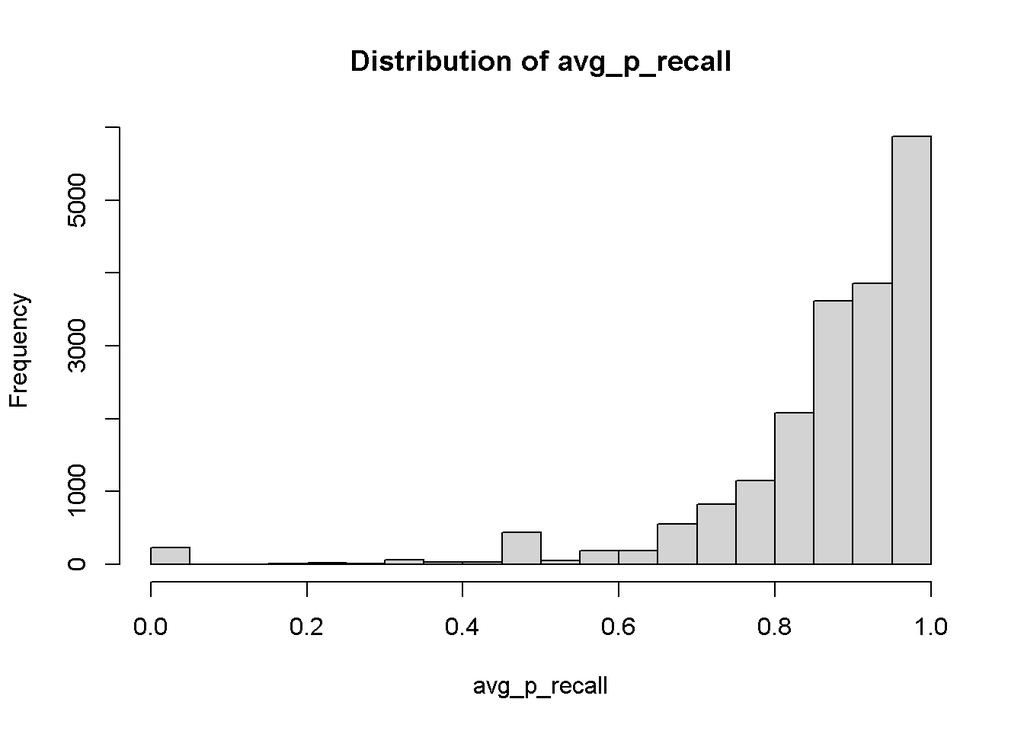

```r
# Histogram to explore the distribution of avg_p_recall
hist(spaced_repetition_effectiveness$avg_p_recall, breaks = 20, main = "Distribution of avg_p_recall", xlab = "avg_p_recall")
```

Considering the histogram is skewed left, it appears that the participants are recalling most of the words correctly. The mean of all average proportion session recalls is 0.8674 while the median exists at a high 0.9013. Therefore, the spaced repetition approach employed by Duolingo appears to be arguably effective. However, we should also look further into the different types of variables and how they may potentially affect the learning performances

**2. Are there any patterns in user performance based on time since the last practice?**

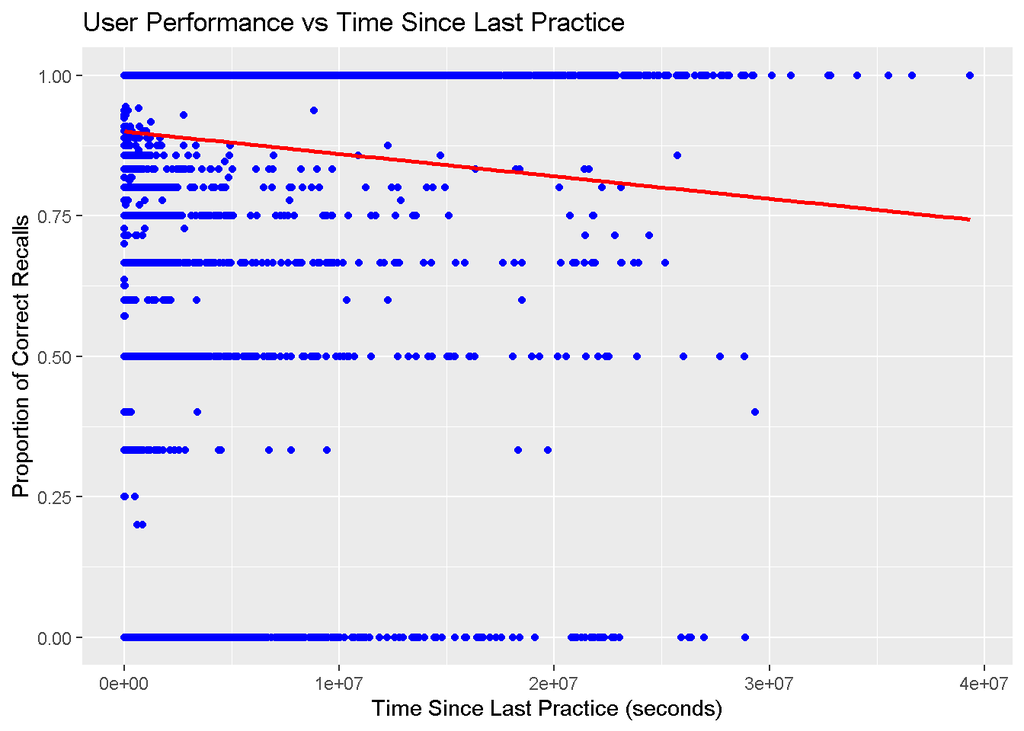

```r
# We are going to be using the sample size 5000 because the original data frame has over 1.2 million observations and it will take too long for the plot codes to load with that data size
sample_size <- 50000  # Adjust as needed

#  The original dataset is too large to efficiently plot every value
sampled_data <- sample_n(duo_data, sample_size)

performance_vs_delta <- sampled_data |>
  ggplot(aes(x = delta, y = p_recall)) +
  geom_point(color = "blue") +
  geom_smooth(method = "lm", se = FALSE, color = "red") +
  labs(x = "Time Since Last Practice (seconds)", y = "Proportion of Correct Recalls", title = "User Performance vs Time Since Last Practice")

# Display the plot
performance_vs_delta
```

The performance_vs_delta graph shows there is a slight negative connotation between performance and the time since the last practice.

**Bonus sub-question: Are participants more likely to recall a word with shorter spaced repetition time intervals?**

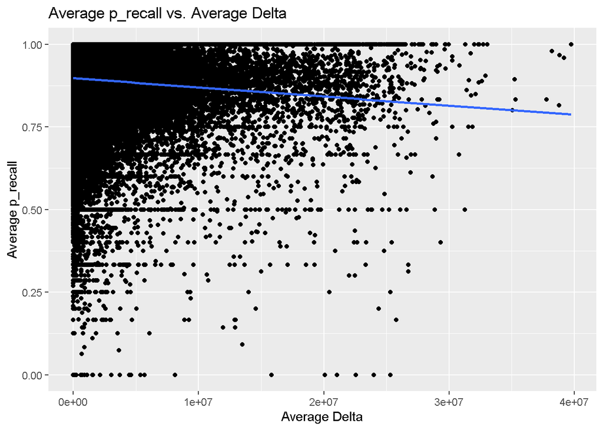

```r
# Create ggplot for avg_p_recall vs avg_delta with smoothed line
plot_spaced_rep <- ggplot(user_summary, aes(x = avg_delta, y = avg_p_recall)) +
  geom_point() +
  geom_smooth(method = "lm", se = FALSE) +  # Add a linear regression line without confidence interval
  labs(x = "Average Delta", y = "Average p_recall", title = "Average p_recall vs. Average Delta")

plot_spaced_rep
```

According to the graph above, users generally perform better when the spaced repetition time intervals are shorter. This observation holds true across a range of delta values, from 0 seconds to up to 463 days. It implies that users may experience improved learning outcomes with consistent and frequent study sessions on Duolingo.

**3. Does the user interface language affect the user’s performance?**

```r
ui_language_performance <- duo_data |>
  group_by(ui_language) |>
  summarise(avg_p_recall = mean(p_recall))

ui_language_performance
```

```
# A tibble: 4 × 2
  ui_language avg_p_recall
  <chr>              <dbl>
1 English            0.895
2 Italian            0.910
3 Portuguese         0.899
4 Spanish            0.896
```

```r
summary(ui_language_performance$avg_p_recall)
```

```
   Min. 1st Qu.  Median    Mean 3rd Qu.    Max.
 0.8950  0.8960  0.8975  0.8999  0.9014  0.9096
```

```r
standard_deviation <- sd(ui_language_performance$avg_p_recall)
standard_deviation
```

```
[1] 0.006650745
```

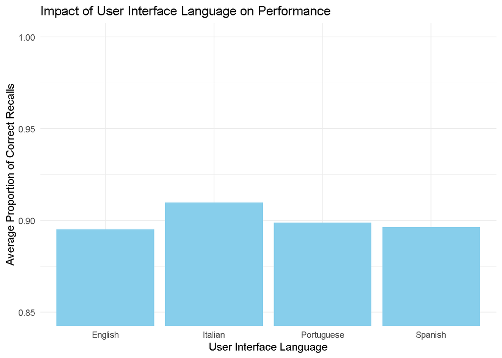

```r
ggplot(ui_language_performance, aes(x = ui_language, y = avg_p_recall)) +
  geom_bar(stat = "identity", fill = "skyblue", na.rm = TRUE) +
  theme_minimal() +
  labs(x = "User Interface Language", y = "Average Proportion of Correct Recalls", title = "Impact of User Interface Language on Performance") + coord_cartesian(ylim = c(0.85, 1))
```

It seems that there is minimal variation in user performance across different user interface languages, as indicated by the low standard deviation observed for all languages. Furthermore, the plot depicting performance by language reveals only subtle differences between the bars, which become more apparent when zooming in on the range between 0.85 and 1.

Arguably, users who have Italian set as their user interface language exhibit slightly better performance compared to users with other languages.

Still, the differences are really minimal.

I am going to add new columns to our user_summary data frame. I will be specifying the languages each user is learning and the languages they use in their UI. This will be used when answering question 5.

```r
user_learning <- distinct(duo_data, user_id, learning_language)


user_learning <- user_learning |>
  group_by(user_id) |>
  summarize(learning = toString(learning_language))

user_summary <- user_summary |>
  left_join(user_learning, by = "user_id")

user_ui_language <- distinct(duo_data, user_id, ui_language)

user_ui_language <- user_ui_language |>
  group_by(user_id) |>
  summarize(ui_languages = toString(ui_language))

# Merge the ui_language information into user_summary
user_summary <- user_summary |>
  left_join(user_ui_language, by = "user_id")

user_summary
```

```
# A tibble: 115,222 × 7
   user_id avg_history_recall avg_p_recall num_occurrences avg_delta learning
   <fct>                <dbl>        <dbl>           <int>     <dbl> <chr>
 1 u:--N                0.875        0.810              32 15105609. German
 2 u:--U                0.905        0.929               7  5608727  German
 3 u:-_-                0.912        0.905             152   671605. German
 4 u:-_D                0.929        0.5                14 12767600. Spanish
 5 u:-3I                0.905        0.9                14   283420. French
 6 u:-3n                0.894        0.830             124 11269398. Spanish
 7 u:-4V                0.932        0.874             215  3142199. German, Fr…
 8 u:-4y                0.919        0.944              68  5354884. Spanish
 9 u:-5I                0.801        0.885              39   629067. German
10 u:-69                0.892        0.811              15 13550005. French
# ℹ 115,212 more rows
# ℹ 1 more variable: ui_languages <chr>
```

**4. What are the most challenging words for users?**

I will reuse the data frame from question 1.

```r
top_challenging_lexemes <- spaced_repetition_effectiveness |>
  arrange(avg_p_recall) |>
  head(100)

top_challenging_lexemes
```

```
# A tibble: 100 × 2
   lexeme_id                        avg_p_recall
   <fct>                                   <dbl>
 1 01887462f7ebffbd51e1ce584f52ab46            0
 2 032d211238829c77fcae70ba6cbd9baa            0
 3 0448efe1a8ce9a9a82591211c6851319            0
 4 056f2cd86a76d02956cc3b4166ddf8d5            0
 5 05bcf33b480493bba79420cd3fda19bf            0
 6 0849ef6f8c6a8bc3e852bba498399fd5            0
 7 0adb615b97a994c771898fd19a2824e4            0
 8 0bb66e53a0b008ca866b10f37819e48e            0
 9 114bb084c98f5ca1a1e1a4e4424c0940            0
10 11721ecdb20febdc3a42e12f21704502            0
# ℹ 90 more rows
```

**Bonus sub-question: what type of words are participants are having most difficulty recalling?**

```r
# Merge top_challenging_lexemes with duo_data to get lexeme_string
challenging_lexemes_with_string <- top_challenging_lexemes |>
  left_join(duo_data, by = "lexeme_id") |>
  select(lexeme_id, lexeme_string, p_recall)

# View the correlated lexeme_id and lexeme_string
challenging_lexemes_with_string
```

```
# A tibble: 119 × 3
   lexeme_id                        lexeme_string                       p_recall
   <fct>                            <chr>                                  <dbl>
 1 01887462f7ebffbd51e1ce584f52ab46 dis/dire<vblex><pri><p2><sg>               0
 2 032d211238829c77fcae70ba6cbd9baa <*sf>/limite<n><f><*numb>                  0
 3 0448efe1a8ce9a9a82591211c6851319 olhos/olho<n><m><pl>                       0
 4 056f2cd86a76d02956cc3b4166ddf8d5 revoir/revoir<vblex><inf>                  0
 5 05bcf33b480493bba79420cd3fda19bf gruppen/gruppe<n><f><pl><dat>              0
 6 0849ef6f8c6a8bc3e852bba498399fd5 beschluss/beschluss<n><m><sg><*cas…        0
 7 0adb615b97a994c771898fd19a2824e4 <*sf>/notion<n><f><*numb>                  0
 8 0adb615b97a994c771898fd19a2824e4 <*sf>/notion<n><f><*numb>                  0
 9 0bb66e53a0b008ca866b10f37819e48e parlais/parler<vblex><pii><p2><sg>         0
10 0bb66e53a0b008ca866b10f37819e48e parlais/parler<vblex><pii><p2><sg>         0
# ℹ 109 more rows
```

Let’s find the most common sub strings (only alphabetical letters) that exists between < and > in lexeme_string. These sub strings usually tells us what kind of word did the user encounter in their duolingo exercise context. Was it a noun? verb? plural? singular? etc.

```r
substrings <- str_extract_all(challenging_lexemes_with_string$lexeme_string, "(?<=<)[^<>]+(?=>)")

# Flatten the list of sub strings
all_substrings <- unlist(substrings)

# Count the frequency of each sub string
substring_counts <- table(all_substrings)

# Sort the sub strings by frequency in descending order
sorted_substrings <- sort(substring_counts, decreasing = TRUE)

top_10_substrings <- head(sorted_substrings, 10)
top_10_substrings
```

```
all_substrings
    n    sg vblex *numb   *sf     f    pl     m   pri    p3
   65    42    38    37    37    34    34    27    18    13
```

Here’s a breakdown of what each of the top 10 sub string tells about a word:

n: noun,

sg: singular form,

vblex: verb,

sf: the surface form is the same as the base form,

f: feminine gender,

pl: plural form,

m: masculine gender,

pri: primary form,

p3: third person singular,

These top 10 sub strings suggest that Duolingo users in this data set may be encountering most difficulties with nouns, verbs, gender distinctions, and possibly numerical concepts in their language learning exercises.

**5. Is there any correlation between the user’s history with a word and their performance in the current session?**

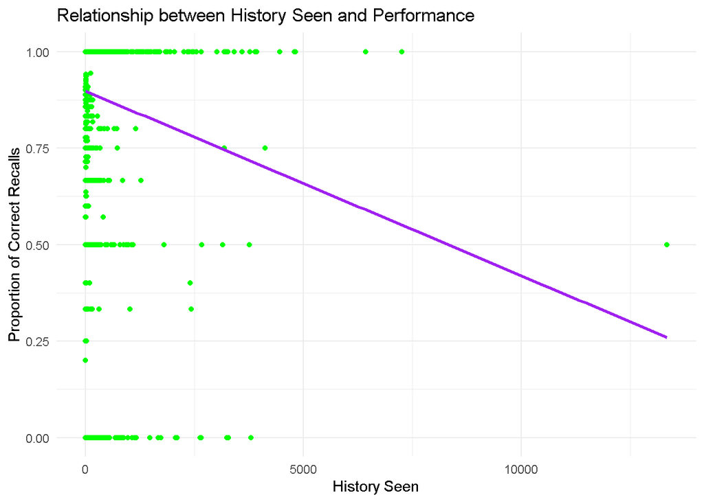

```r
history_vs_performance <- sampled_data |>
  ggplot(aes(x = history_seen, y = p_recall)) +
  geom_point(color = "green") +
  geom_smooth(method = "lm", se = FALSE, color = "purple") +
  theme_minimal() +
  labs(x = "History Seen", y = "Proportion of Correct Recalls", title = "Relationship between History Seen and Performance")

# Displaying  the plot
history_vs_performance
```

It appears there are outliers (above 1000) for history_seen

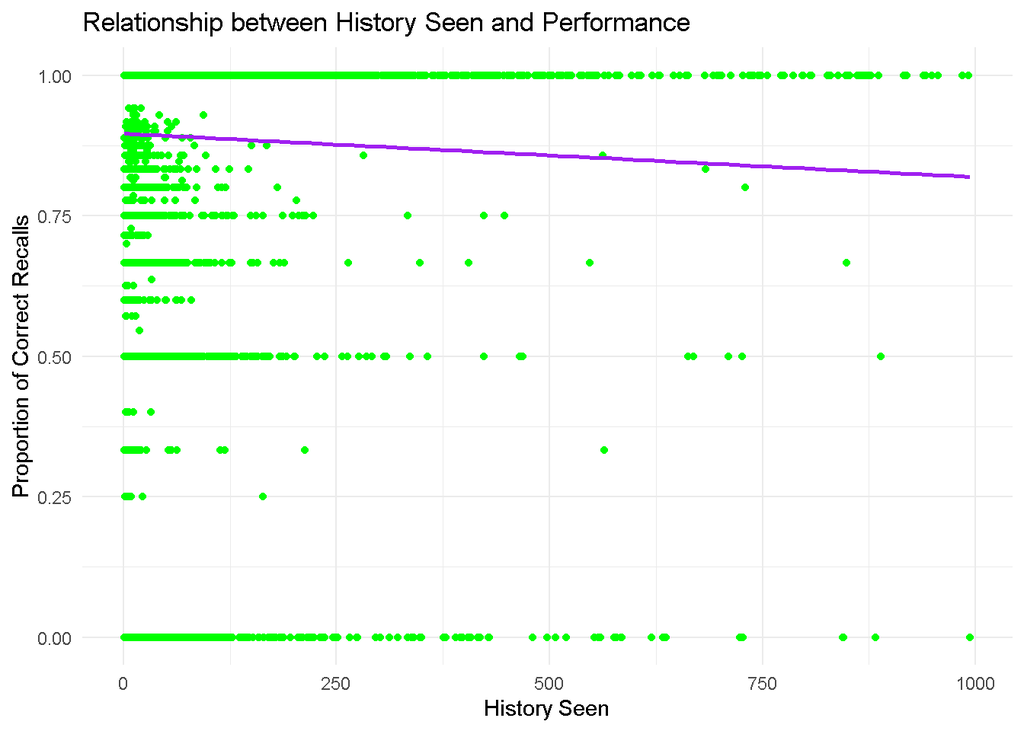

```r
#Using filter to make a subset and remove the one outlier above 10000
duo_data_filtered <- duo_data |>
  filter(history_seen <= 1000)

# Now 'duo_data_filtered' contains the data without outliers where a word has been seen over 1000 times
samp_data <- sample_n(duo_data_filtered, sample_size)

hist_vs_performance <- samp_data |>
  ggplot(aes(x = history_seen, y = p_recall)) +
  geom_point(color = "green") +
  geom_smooth(method = "lm", se = FALSE, color = "purple") +
  theme_minimal() +
  labs(x = "History Seen", y = "Proportion of Correct Recalls", title = "Relationship between History Seen and Performance")

hist_vs_performance
```

Surprisingly, there is also a slight negative relation between a user’s ability to recall a word and the number of times the word has already been studied/seen. Perhaps certain words are too difficult. Thus, a user may require more repetitions to fully learn the word(?). After all, it is common for the duolingo algorithm to show a word less if the user has a high recall rate on it after a few tries.

*What if a user’s performance and training is not dependent on repetition but their previous accuracy score on the word?*

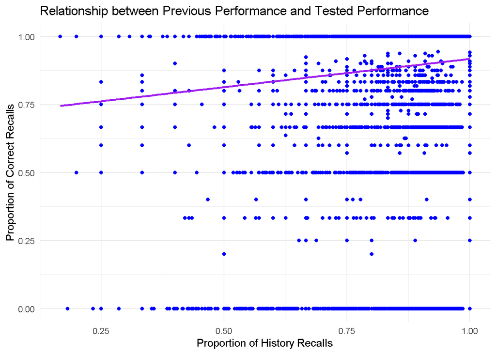

```r
historyrecall_vs_performance <- sampled_data |>
  ggplot(aes(x = history_recall, y = p_recall)) +
  geom_point(color = "blue") +
  geom_smooth(method = "lm", se = FALSE, color = "purple") +
  theme_minimal() +
  labs(x = "Proportion of History Recalls", y = "Proportion of Correct Recalls", title = "Relationship between Previous Performance and Tested Performance")

historyrecall_vs_performance
```

The above graph suggests that for many words, a user’s session performance is correlated to the user’s history performance

*How about we assess each user’s overall average performances*

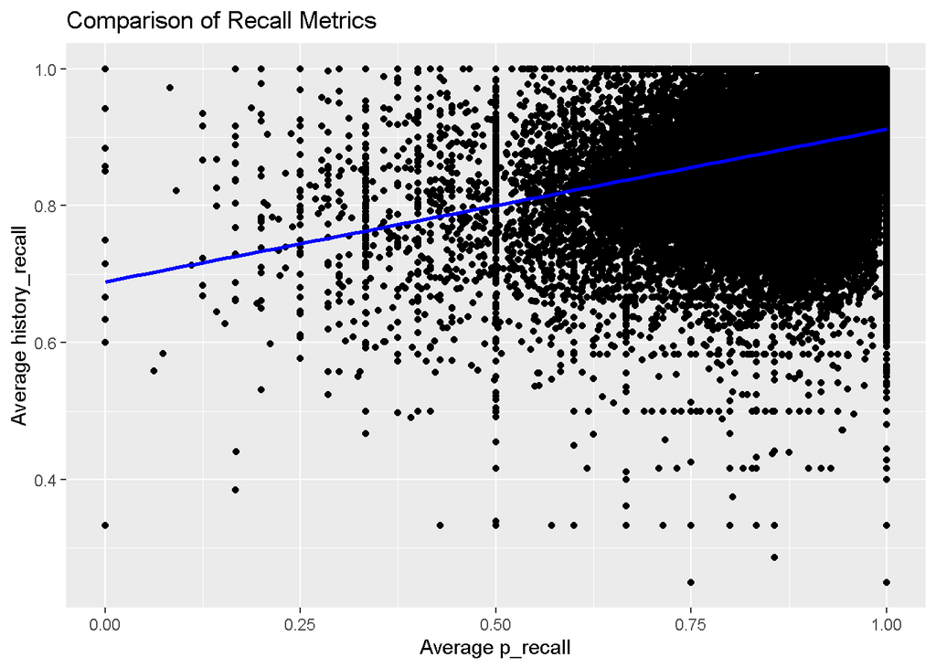

```r
# Comparing avg_p_recall and avg_history_recall for each user_id
user_perfom <- ggplot(user_summary, aes(x = avg_p_recall, y = avg_history_recall)) +
  geom_point() +
  geom_smooth(method = "lm", se = FALSE, color = "blue") +
  labs(x = "Average p_recall", y = "Average history_recall", title = "Comparison of Recall Metrics")

user_perfom
```

There is strong evidence suggesting that participants tend to perform well on their session recalls when they also excel in their history recalls.

Let’s remake the graph that shows the different types of UI languages

```r
user_perform <- ggplot(user_summary, aes(x = avg_p_recall, y = avg_history_recall, color = ui_languages)) +
  geom_point() +
  geom_smooth(method = "lm", se = FALSE, color = "blue")
  labs(x = "Average p_recall", y = "Average history_recall", title = "Comparison of Recall Metrics")
```

```
$x
[1] "Average p_recall"

$y
[1] "Average history_recall"

$title
[1] "Comparison of Recall Metrics"

attr(,"class")
[1] "labels"
```

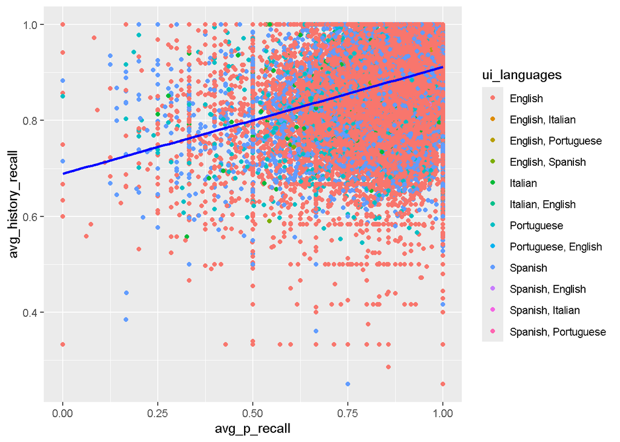

```r
user_perform
```

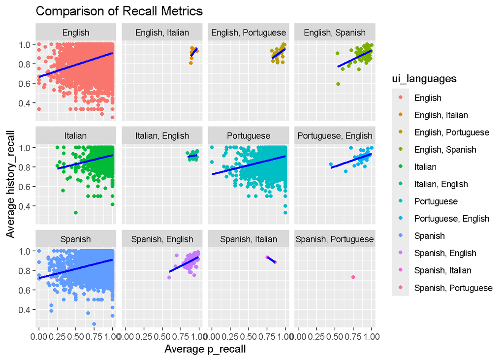

```r
user_perform <- ggplot(user_summary, aes(x = avg_p_recall, y = avg_history_recall, color = ui_languages)) +
  geom_point() +
  geom_smooth(method = "lm", se = FALSE, color = "blue") +
  labs(x = "Average p_recall", y = "Average history_recall", title = "Comparison of Recall Metrics") +
  facet_wrap(~ ui_languages)

user_perform
```

### **Summary: Main Findings**

1. The spaced repetition approach employed by Duolingo appears effective, as indicated by high proportions of correct word recalls.
2. User performance tends to decrease slightly with longer intervals since the last practice session, suggesting better performance with shorter intervals. Users generally perform better with shorter spaced repetition time intervals, implying improved learning outcomes with consistent study sessions.
3. The user interface language has minimal impact on user performance, with subtle differences observed among languages. However, users with Italian set as their UI language exhibit slightly better performance.
4. The most challenging words for users include nouns, verbs, and gender distinctions, suggesting difficulty with these concepts.
5. There’s a slight negative correlation between a user’s history with a word and their performance in the current session, indicating the need for more repetitions for certain words. On average, however, for each user, users tend to perform well in current sessions when they excel in previous ones, regardless of language or UI language.